# Bayes Theorem (Key)

Bayes' Theorem gives us a way to *invert* conditional probabilities. The formula comes from the definition of conditional probability

$$P(A|B) = \dfrac{P(A \cap B)}{P(B)}$$

this implies the following

$$P(A \cap B) = P(A|B)P(B) = P(B|A)P(A)$$

Solving for $P(A|B)$ we get

$$P(A|B) = \dfrac{P(B|A)P(A)}{P(B)}$$

Though this is the final form, in practice you will need to compute $P(B)$ using the following

$$P(B) = P(B|A)P(A) + P(B|\overline{A})P(\overline{A})$$

which says the probability of $B$ is the sum of the probability of $B$ intersect $A$ and $B$ intersect not $A$. ($A$ is either true or false so these are the only two options)

## Exercise 1: Plot a Venn Diagram

Using matplotlib, draw a simple Venn diagram representing two sets $A$, $B$ with a non-null intersection.

```python
!pip install matplotlib_venn
# run this and then delete the cell so it doesn't get saved
```

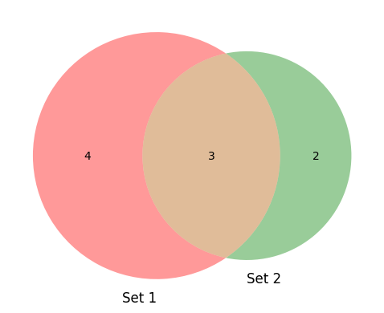

```python
# Solution from google search embedded generative-AI

import matplotlib.pyplot as plt
from matplotlib_venn import venn2, venn3

# For a 2-set Venn diagram
set1 = {1, 2, 3, 4, 5,10,20}
set2 = {3, 4, 5,6,7}

venn2([set1, set2], ('Set 1', 'Set 2'))
plt.show()
```

## Exercise 2: Compute Bayes' Probabilities

We want to replicate the computation carried out in class. If a doctor performs a test that has a given accuracy, for a disease with a given incidence rate, determine the probability that a randomly selected person with a positive test result has the disease. You are given *accuracy* and *incidence* as input, both in the range $(0,1]$

```python
def get_bayes_probability(acc, inc):
    prob_pos_given_sick = acc
    prob_pos_given_not_sick = 1-acc
    prob_sick = inc
    prob_not_sick = 1-inc
    prob_pos = prob_pos_given_sick * prob_sick + \
               prob_pos_given_not_sick * prob_not_sick
    bayes = (prob_pos_given_sick)*prob_sick / prob_pos
    return bayes
```

Check some results below. The first one comes from class

```python
get_bayes_probability(0.97,0.001)
```

```
0.031351001939237205
```

```python
get_bayes_probability(0.97,0.01)
```

```
0.24619289340101508
```

```python
get_bayes_probability(0.97,0.1)
```

```
0.7822580645161289
```

```python
get_bayes_probability(0.99,0.001)
```

```
0.09016393442622944
```

```python
get_bayes_probability(0.50,0.001)
```

```
0.001
```

## Exercise 3: Plot

You will create two plots in the section. For a fixed incidence rate, plot the bayes probability as the accuracy of the test ranges from 0 to 100%.

Then, for a fixed accuracy, plot the bayes probability as the incidence rate increases.

**Note**, to avoid 1/0 errors you'll probably want to *not* go all the way to 0 or 1.

State a conclusion about the results. What's the correlation? What do you observe? What do you think about accuracy measures for tests now?

Hint: create two arrays `X,Y` (python lists) of the same length containing the X values in one array and the Y values in another. List comprehensions are the best way to do this in python, though a for loop is fine too (append to an initially empty list)

then use `plt.plot(X,Y)`

```python
from matplotlib import pyplot as plt
```

```python
acc = 0.97
X = [i/100.0 for i in range(1,100)]
Y = [get_bayes_probability(acc, inc/100) for inc in range(1,100)]
```

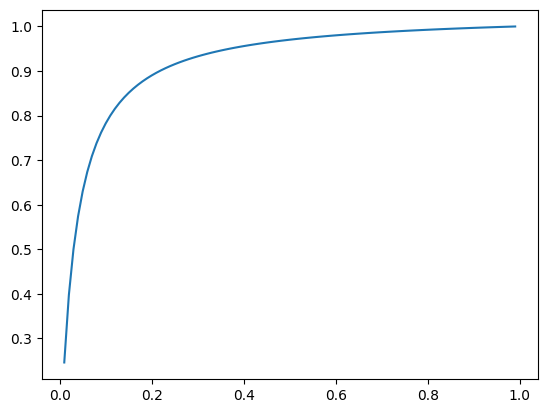

```python
plt.plot(X,Y);
```

```python
inc = 0.97
X = [i/100.0 for i in range(1,100)]
Y = [get_bayes_probability(acc/100, inc) for acc in range(1,100)]
```

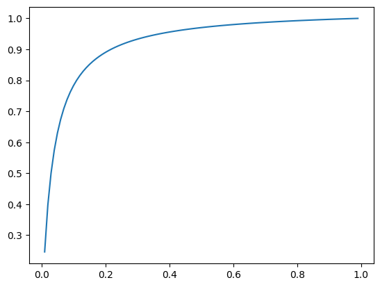

```python
plt.plot(X,Y);
```

Now go back and beautify your plots. Add a title and a legend. Some axis labels. Maybe read about matplotlib styles and change up the colors. Try a different type of plot. Just experiment some. Results below.

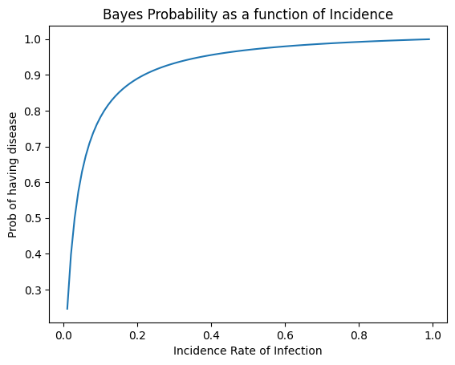

```python
plt.title("Bayes Probability as a function of Incidence")
plt.xlabel("Incidence Rate of Infection")
plt.ylabel("Prob of having disease")
plt.plot(X,Y)
```

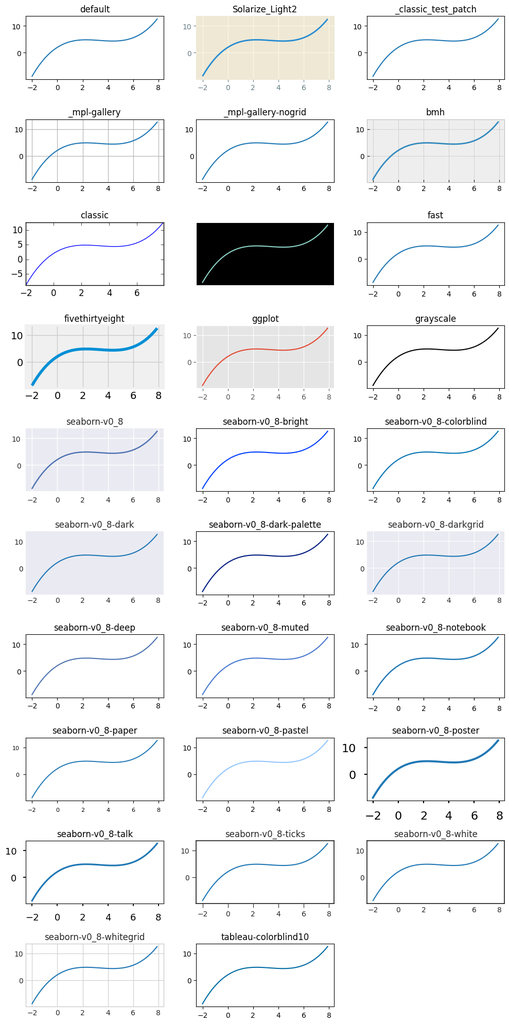

```python
# from https://www.dunderdata.com/blog/view-all-available-matplotlib-styles

import matplotlib.pyplot as plt
import numpy as np

x = np.arange(-2, 8, .1)
y = .1 * x ** 3 - x ** 2 + 3 * x + 2

fig = plt.figure(dpi=100, figsize=(10, 20), tight_layout=True)
available = ['default'] + plt.style.available
for i, style in enumerate(available):
    with plt.style.context(style):
        ax = fig.add_subplot(10, 3, i + 1)
        ax.plot(x, y)
    ax.set_title(style)
```

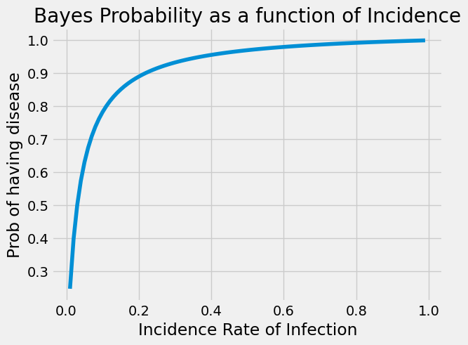

```python
with plt.style.context("fivethirtyeight"):
    plt.title("Bayes Probability as a function of Incidence")
    plt.xlabel("Incidence Rate of Infection")
    plt.ylabel("Prob of having disease")
    plt.plot(X,Y)
```

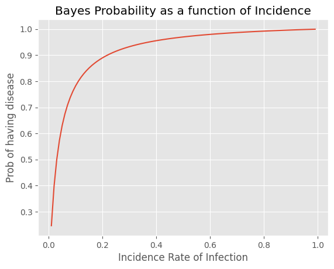

```python
with plt.style.context("ggplot"):
    plt.title("Bayes Probability as a function of Incidence")
    plt.xlabel("Incidence Rate of Infection")
    plt.ylabel("Prob of having disease")
    plt.plot(X,Y)
```